# data-understanding

## Homework 1

**Name**: Carlos M.

Remember that you are encouraged to discuss the problems with your instructors and classmates, but **you must write all code and solutions on your own**.

The rules to be followed for the assignment are:

- Do **NOT** load additional packages beyond what we've shared in the cells below.
- Some problems with code may be autograded. If we provide a function or class API **do not** change it.
- Do not change the location of the data or data directory. Use only relative paths to access the data.

```python
import argparse
import pandas as pd
import numpy as np
import pickle
from pathlib import Path
```

### Problem 1 - [10 points]

The Function below should return the following attributes for the ith column:

- Number of objects
- The minimum value
- The maximum value
- The mean value
- The standard deviation value
- The Q1 value
- The median value
- The Q3 value
- The IQR value

Note:

- A sample dataset to test your code has been provided in the location "data/dataset.csv". Please maintain this as it would be necessary while grading.
- Do not change the variable names of the returned values.
- After calculating each of those values, assign them to the corresponding value that is being returned.
- The ithAttribute value can range from 0 - 10

```python
def calculate(dataFile, col_num):
    """
    Input Parameters:
        dataFile: The dataset file.
        ithAttre: The ith attribute for which the various properties must be calculated.

    Default value of 0,infinity,-infinity are assigned to all the variables as required.
    """
    numObj, minValue, maxValue, mean, stdev, Q1, median, Q3, IQR = [0,"inf","-inf",0,0,0,0,0,0]
    #YOUR TASK: Write code to assign the values to the respective variables.

    # your code here
    df = pd.read_csv(dataFile)
    dat = df.iloc[:,col_num]

    numObj = len(dat)
    minValue = dat.min()
    maxValue = dat.max()
    mean = dat.mean()
    stdev = dat.std()
    Q1 = dat.quantile(0.25)
    median = dat.median()
    Q3 = dat.quantile(0.75)
    IQR = Q3-Q1


    return numObj, minValue, maxValue, mean, stdev, Q1, median, Q3, IQR
```

```python
'''
This cell has hidden test cases that will run after you submit your assignment.
You can troubleshoot using the unit tests we shared below.
'''
```

```
'\nThis cell has hidden test cases that will run after you submit your assignment. \nYou can troubleshoot using the unit tests we shared below.\n'
```

### Here are the unit tests. You don't need to modify them. Simply execute the cell and observe the output.

```python
import unittest

class TestKnn(unittest.TestCase):
    def setUp(self):
        self.loc = "data/dataset.csv"
        file = open('data/testing', 'rb')
        self.data = pickle.load(file)
        file.close()

    def test0(self):
        """
        Test the label counter
        """
        self.column = self.data[0]
        result = calculate(self.loc,self.column)
        self.assertEqual(result[0],self.data[1][0])
        self.assertAlmostEqual(result[1],self.data[1][1], places = 3)
        self.assertAlmostEqual(result[2],self.data[1][2], places = 3)
        self.assertAlmostEqual(result[3],self.data[1][3], places = 3)
        self.assertAlmostEqual(result[4],self.data[1][4], places = 3)
        self.assertAlmostEqual(result[5],self.data[1][5], places = 3)
        self.assertAlmostEqual(result[6],self.data[1][6], places = 3)
        self.assertAlmostEqual(result[7],self.data[1][7], places = 3)
        self.assertAlmostEqual(result[8],self.data[1][8], places = 3)

tests = TestKnn()
tests_to_run = unittest.TestLoader().loadTestsFromModule(tests)
unittest.TextTestRunner().run(tests_to_run)
```

```
.
----------------------------------------------------------------------
Ran 1 test in 0.022s

OK
```

```
<unittest.runner.TextTestResult run=1 errors=0 failures=0>
```

### Problem 2 - [10 Points]

The helper function `func()` below will be used to help generate a scatter plot of the columns CO on the x-axis and AFDP on the y-axis and should return the following:

- Return the x values, y values, title, x-label and the y-label

Notes:

- The dataset is available in "./data/dataset.csv"
- Hidden tests are run against x and y values. These should be array-like objects (list or series).

Use the cell below to add your code.

```python
# Scatter plot of columns with attributes CO on x-axis and AFDP on y-axis
# Return the x values, y values, title, x-label and the y-label
# The dataset is available in "./data/dataset.csv"
import pandas as pd
import numpy as np
import matplotlib.pyplot as plt

def func():

    '''
        Output: x, y, title, x-label, y-label
    '''
    x = []
    y = []
    title = ''
    x_label = ''
    y_label = ''

    # your code here
    df = pd.read_csv("./data/dataset.csv")

    x = df['CO']
    y = df['AFDP']
    title = 'AFDP vs CO'
    x_label = 'CO'
    y_label = 'AFDP'


    return x, y, title, x_label, y_label
```

## The cell below can be used to test our scatter plot. You don't need to modify this. Simply execute the cell below and observe the output.

Once the `func()` function above has been completed we can test it by running the cell below. Running the cell below should simply output a scatter plot based on your `func()` function. Your scatter plot may not look exactly the same, but may look something like this:

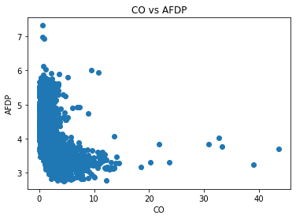

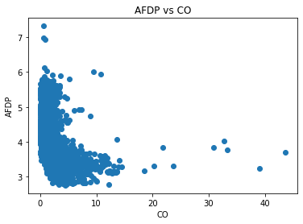

```python
# Testing the func() function
x, y, title, x_label, y_label = func()
plt.scatter(x, y)
plt.title(title)
plt.xlabel(x_label)
plt.ylabel(y_label)
```

```python
'''
This cell has hidden test cases that will run after you submit your assignment.
You can troubleshoot by calling the function and checking return types and values.
'''
```

```
'\nThis cell has hidden test cases that will run after you submit your assignment. \nYou can troubleshoot by calling the function and checking return types and values.\n'
```